# More Info - Contributors to Teen Birth Rate

Dara Zirlin, Ran Ji

Last updated on 2019-05-30

### Question

How is teen birth rate related to adult unemployment, adult education level, and median household income? We look at the relationship at the county level. Further, how do teen birth rates differ by region?

### Datasets

- Teen birth rates
  - Link: https://catalog.data.gov/dataset/teen-birth-rates-for-age-group-15-19-in-the-united-states-by-county
  - Estimated teen birth rates for age group 15-19 (expressed per 1000 females aged 15-19) by county and year
  - Used data for 2015
- Education
  - Link: https://www.ers.usda.gov/data-products/county-level-data-sets/download-data/
  - Percentage of adults in each of four categories
    - Did not receive high school diploma
    - Only received high school diploma
    - Some college or associate’s degree
    - Received college degree or higher
  - Used average value across 2013-2017
- Unemployment
  - Link: https://www.ers.usda.gov/data-products/county-level-data-sets/download-data/
  - Percent of labor force (people with a job or actively looking for one) without a job
  - Used data for 2015

### Graphics

Below, we plot our independent variables against teen birth rates.

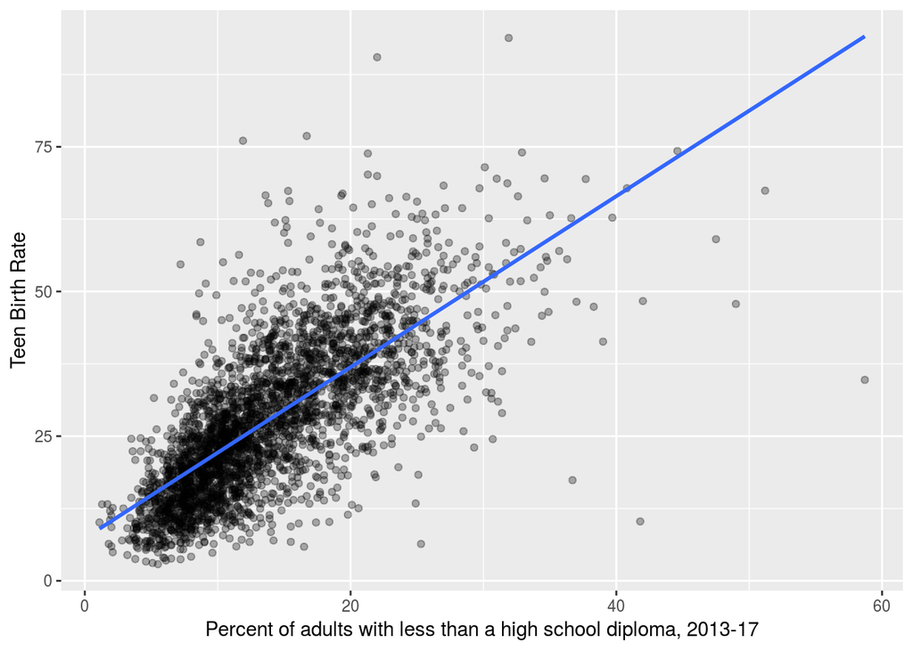

There appears to be a clear positive relationship between teen birth rates and the percent of adults with less than a high school diploma.

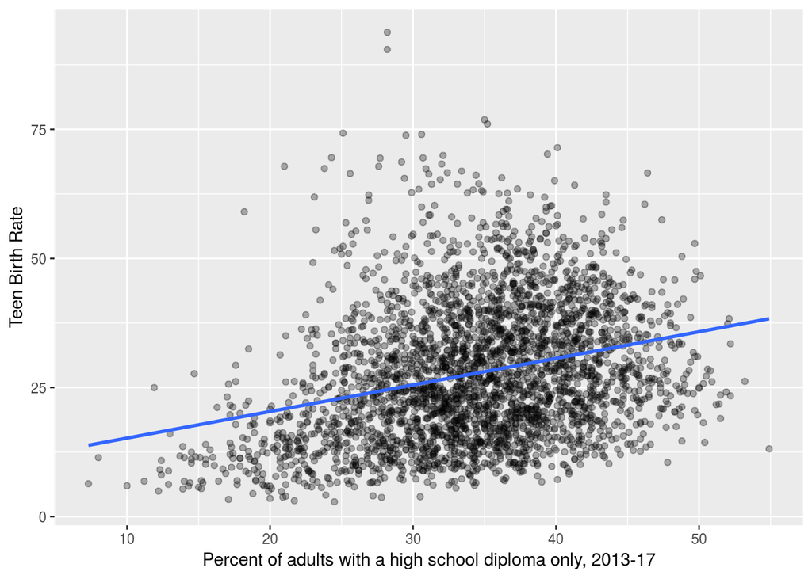

While teen birth rates and the percent of adults with only a high school diploma do appear to be positively correlated, the relationship appears less strong.

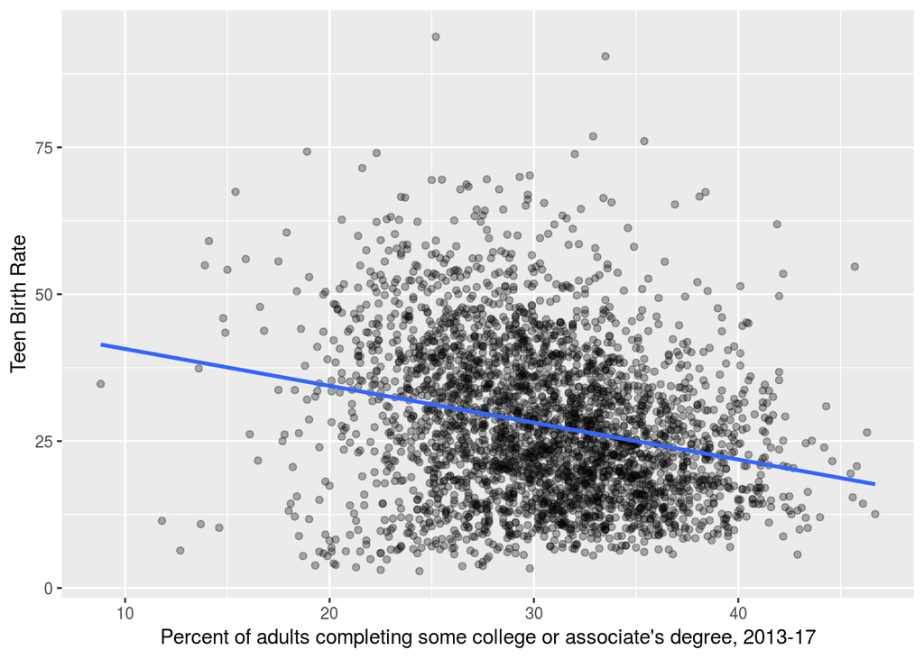

There appears to be a weak negative relationship between teen birth rates and the percent of adults with some college or associate’s degree.

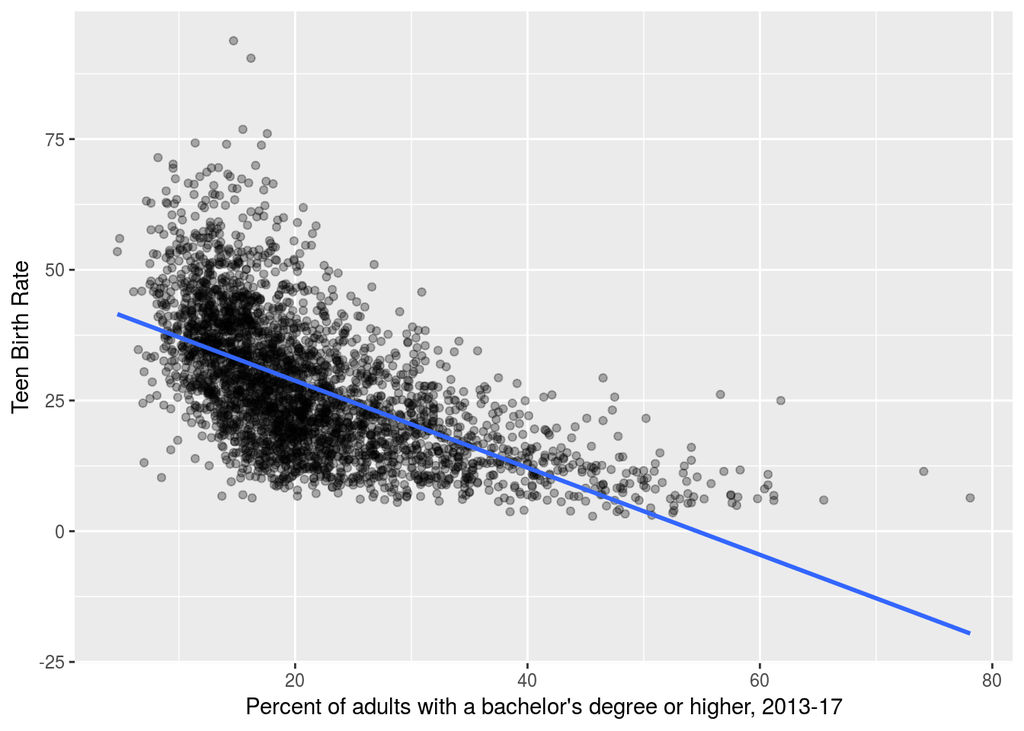

There is a clear relationship between percent of adults with a bachelor’s degree or higher and teen birth rates, though it does not appear to be linear.

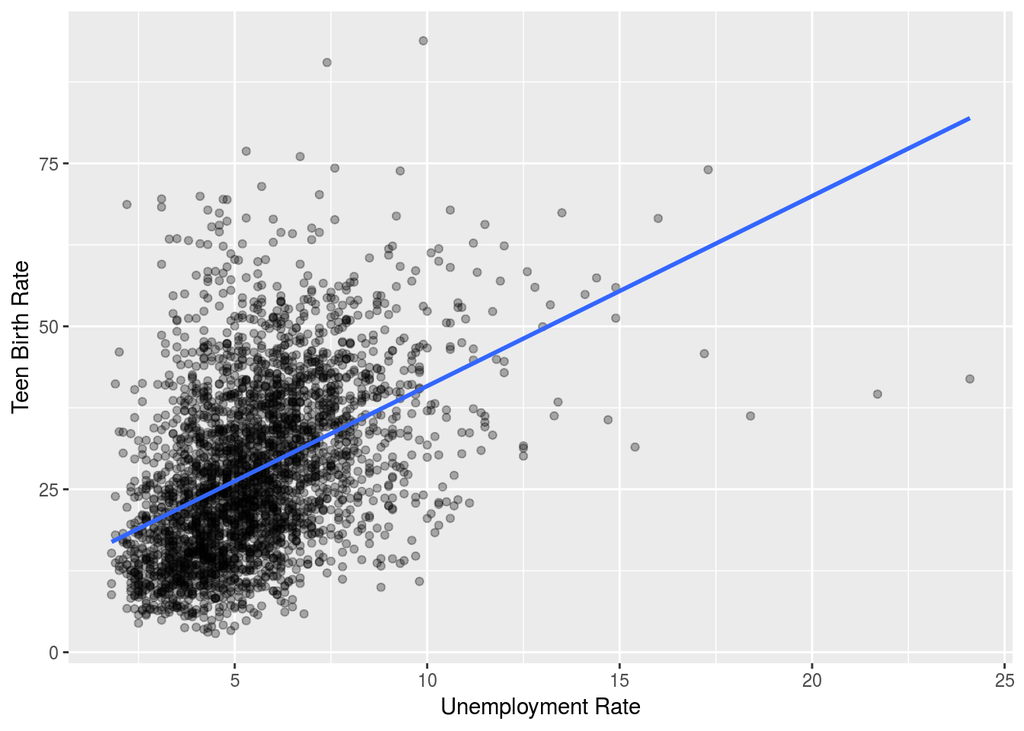

There’s a positive relationship between unemployment rate and teen birth rate.

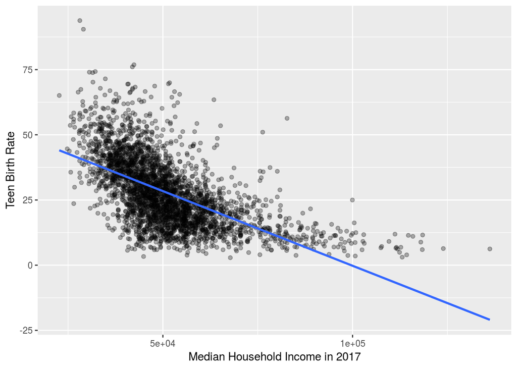

There is a clear relationship between median household income and teen birth rates, though it does not appear to be linear.

Below is a map of the US colored by teen birth rates at the county level.

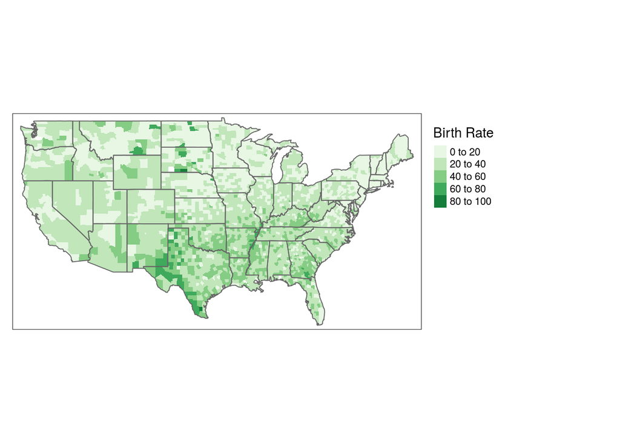

Below is a box plot of teen birth rates by sub-region.

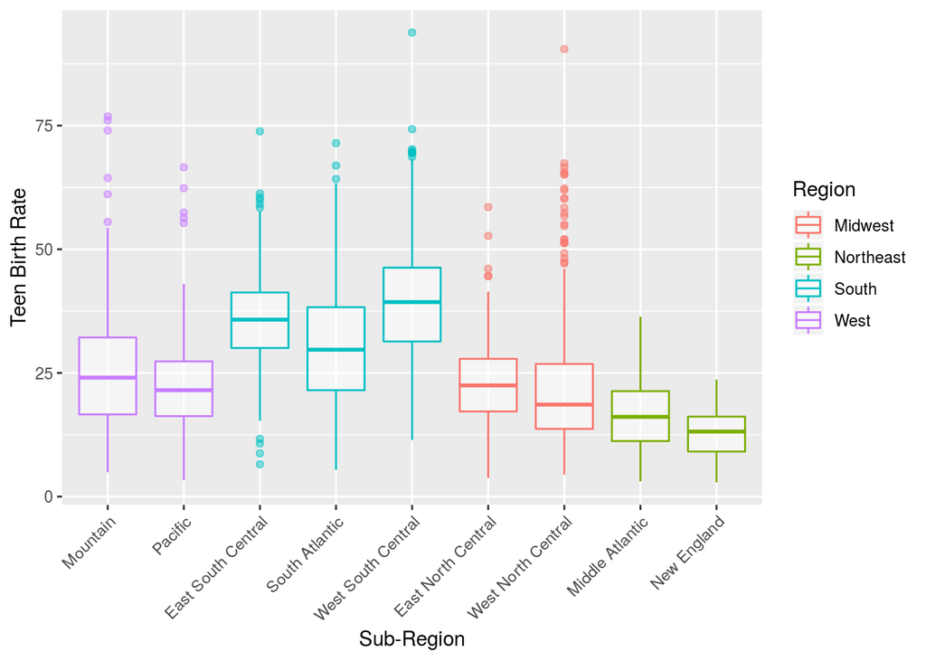

As we noted in the blog post, counties in the South on average, had higher teen birth rates. On average, the Northeast not only had the lowest average teen birth rates, but also the least variable across its counties.

### Linear model of birth rate as a function of unemployment, education level, region, and income

The education data divides the population into four groups: less than high school, high school, college, beyond college. Since the four categories add up to 100%, it is sufficient to only include three of the four rates in the linear model.

Below is the model we discussed in the blog post.

```
##
## Call:
## lm(formula = `Birth Rate` ~ UnemploymentRate + Less_than_high_school +
##     high_school + college + Median_Household_Income_2017 + Region,
##     data = data)
##
## Residuals:
##     Min      1Q  Median      3Q     Max
## -38.687  -5.027  -0.440   4.288  51.202
##
## Coefficients:
##                                Estimate Std. Error t value Pr(>|t|)
## (Intercept)                   3.520e+01  2.463e+00  14.292  < 2e-16 ***
## UnemploymentRate              4.107e-01  8.882e-02   4.625 3.91e-06 ***
## Less_than_high_school         7.726e-01  3.857e-02  20.031  < 2e-16 ***
## high_school                  -1.925e-01  3.941e-02  -4.884 1.09e-06 ***
## college                      -3.545e-01  3.877e-02  -9.144  < 2e-16 ***
## Median_Household_Income_2017 -1.648e-04  1.614e-05 -10.217  < 2e-16 ***
## RegionNortheast              -3.053e+00  6.507e-01  -4.692 2.83e-06 ***
## RegionSouth                   4.833e+00  3.960e-01  12.205  < 2e-16 ***
## RegionWest                    1.631e+00  5.009e-01   3.257  0.00114 **
## ---
## Signif. codes:  0 '***' 0.001 '**' 0.01 '*' 0.05 '.' 0.1 ' ' 1
##
## Residual standard error: 8.055 on 3124 degrees of freedom
##   (2 observations deleted due to missingness)
## Multiple R-squared:  0.6246, Adjusted R-squared:  0.6236
## F-statistic: 649.7 on 8 and 3124 DF,  p-value: < 2.2e-16
```